# TIGAS MPDW KULIAH

ARGADO SAMUEL PANOGU

2025-09-02

## Data

```r
library(lmtest)
library(orcutt)
library(HoRM)
# Input Data IPM Fiktif (2014-2023)
tahunni <- 2014:2023
ipmni <- c(78.81, 79.47, 80.13, 80.66, 81.27, 81.85, 81.9, 82.17, 82.58, 82.96)
dt_ipmni <- data.frame(tahunni, ipmni)

print(dt_ipmni)
```

```
##    tahunni ipmni
## 1     2014 78.81
## 2     2015 79.47
## 3     2016 80.13
## 4     2017 80.66
## 5     2018 81.27
## 6     2019 81.85
## 7     2020 81.90
## 8     2021 82.17
## 9     2022 82.58
## 10    2023 82.96
```

## Membuat Model Awal

```r
# Membuat model regresi OLS (Ordinary Least Squares)
model_awal1 <- lm(ipmni ~ tahunni, data = dt_ipmni)
summary(model_awal1)
```

```
##
## Call:
## lm(formula = ipmni ~ tahunni, data = dt_ipmni)
##
## Residuals:
##      Min       1Q   Median       3Q      Max
## -0.36218 -0.15832 -0.03736  0.12832  0.44691
##
## Coefficients:
##               Estimate Std. Error t value Pr(>|t|)
## (Intercept) -819.43800   59.51897  -13.77 7.48e-07 ***
## tahunni        0.44618    0.02949   15.13 3.60e-07 ***
## ---
## Signif. codes:  0 '***' 0.001 '**' 0.01 '*' 0.05 '.' 0.1 ' ' 1
##
## Residual standard error: 0.2678 on 8 degrees of freedom
## Multiple R-squared:  0.9662, Adjusted R-squared:  0.962
## F-statistic:   229 on 1 and 8 DF,  p-value: 3.601e-07
```

Diperoleh nilai Adjusted R-squared sangat tinggi 0.962 dan koefisien tahun sangat signifikan dengan p-value < 0.001.

## Diagnosis

### 3.1. Diagnosis Visual

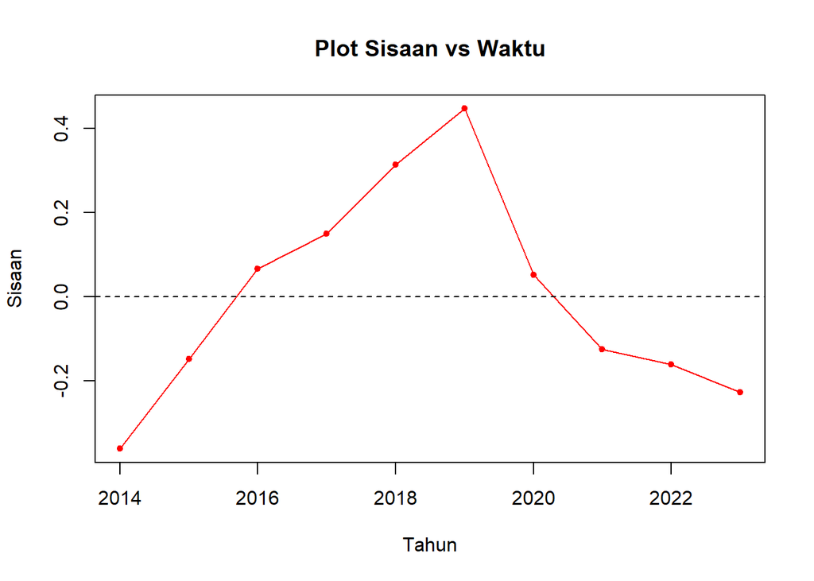

```r
# Ambil sisaan dari model
sisaan_awalni <- residuals(model_awal1)

# Plot sisaan terhadap waktu
plot(dt_ipmni$tahunni, sisaan_awalni, type="o", pch=20, col="red",
     main="Plot Sisaan vs Waktu", xlab="Tahun", ylab="Sisaan")
abline(h=0, lty=2)
```

Diperoleh plot yang menunjukkan pola yang tidak acak, sisaan cenderung berkelompok dengan titik pertama di bawah nol, lalu naik ke atas nol, dan turun lagi, yang dimana hal tersebut gejala visual yang kuat dari autokorelasi positif. Sisaan positif cenderung diikuti sisaan positif, dan sebaliknya.

### 3.2. Diagnosis Formal (Uji Durbin-Watson)

- **H0 (Hipotesis Nol)**: Tidak ada autokorelasi. Sisaan saling bebas.
- **H1 (Hipotesis Alternatif)**: Ada autokorelasi.

```r
dwtest(model_awal1)
```

```
##
##  Durbin-Watson test
##
## data:  model_awal1
## DW = 0.58708, p-value = 0.0001721
## alternative hypothesis: true autocorrelation is greater than 0
```

## Penanganan (Menyembuhkan Model)

### Metode 1: Cochrane-Orcutt

```r
model_coni <- cochrane.orcutt(model_awal1)
summary(model_coni)
```

```
## Call:
## lm(formula = ipmni ~ tahunni, data = dt_ipmni)
##
##                Estimate  Std. Error t value Pr(>|t|)
## (Intercept) -541.645091  117.781243  -4.599 0.002488 **
## tahunni        0.308777    0.058273   5.299 0.001125 **
## ---
## Signif. codes:  0 '***' 0.001 '**' 0.01 '*' 0.05 '.' 0.1 ' ' 1
##
## Residual standard error: 0.1419 on 7 degrees of freedom
## Multiple R-squared:  0.8004 ,  Adjusted R-squared:  0.7719
## F-statistic: 28.1 on 1 and 7 DF,  p-value: < 1.125e-03
##
## Durbin-Watson statistic
## (original):    0.58708 , p-value: 1.721e-04
## (transformed): 1.93290 , p-value: 2.853e-01
```

```r
# rho paling optimum
rhoni <- model_coni$rho
cat("Rho optimum:", rhoni)
```

```
## Rho optimum: 0.6856145
```

Setelah dilakukan penangan menggunakan Cochrane-Orcutt diperoleh nilai dw medekati 2 yang artinya masalah autokorelasi sudah tertangani dengan rho optimum 0.6856145.

```r
ipm.transni <- dt_ipmni$ipmni[-1] - dt_ipmni$ipmni[-10]*rhoni

tahun.transni <- dt_ipmni$tahunni[-1] - dt_ipmni$tahunni[-10]*rhoni
model_co_manualni <- lm(ipm.transni~tahun.transni)

b0_co_manualni <- coef(model_co_manualni)[1]/(1-rhoni)
b1_co_manualni <- coef(model_co_manualni)[2]
cat("Koefisien manual Cochrane-Orcutt:\n")
```

```
## Koefisien manual Cochrane-Orcutt:
```

```r
cat("b0:", b0_co_manualni, "\n")
```

```
## b0: -541.6451
```

```r
cat("b1:", b1_co_manualni, "\n")
```

```
## b1: 0.3087769
```

Diperoleh hasil koefisien manual kita sangat mirip dengan hasil dari fungsi otomatis, yang membuktikan bahwa kita memahami mekanisme di baliknya, untuk perbedaan kecil mungkin terjadi karena fungsi otomatis melakukan beberapa iterasi.

### Metode 2: Hildreth-Lu

```r
hildreth.lu.func<- function(r, model_awal1){
  x <- model.matrix(model_awal1)[,-1]
  y <- model.response(model.frame(model_awal1))
  n <- length(y)
  t <- 2:n
  y <- y[t]-r*y[t-1]
  x <- x[t]-r*x[t-1]

  return(lm(y~x))
}

#Pencarian rho yang meminimumkan SSE
r <- c(seq(0.1,0.9, by= 0.1))
tab <- data.frame("rho" = r, "SSE" = sapply(r, function(i){deviance(hildreth.lu.func(i, model_awal1))}))
round(tab, 4)
```

```
##   rho    SSE
## 1 0.1 0.3106
## 2 0.2 0.2576
## 3 0.3 0.2145
## 4 0.4 0.1813
## 5 0.5 0.1580
## 6 0.6 0.1446
## 7 0.7 0.1411
## 8 0.8 0.1474
## 9 0.9 0.1637
```

```r
rOpt <- seq(0.6,0.8, by= 0.001)
tabOpt <- data.frame("rho" = rOpt, "SSE" = sapply(rOpt, function(i){deviance(hildreth.lu.func(i, model_awal1))}))
head(tabOpt[order(tabOpt$SSE),])
```

```
##      rho       SSE
## 87 0.686 0.1409665
## 86 0.685 0.1409666
## 88 0.687 0.1409673
## 85 0.684 0.1409677
## 89 0.688 0.1409692
## 84 0.683 0.1409698
```

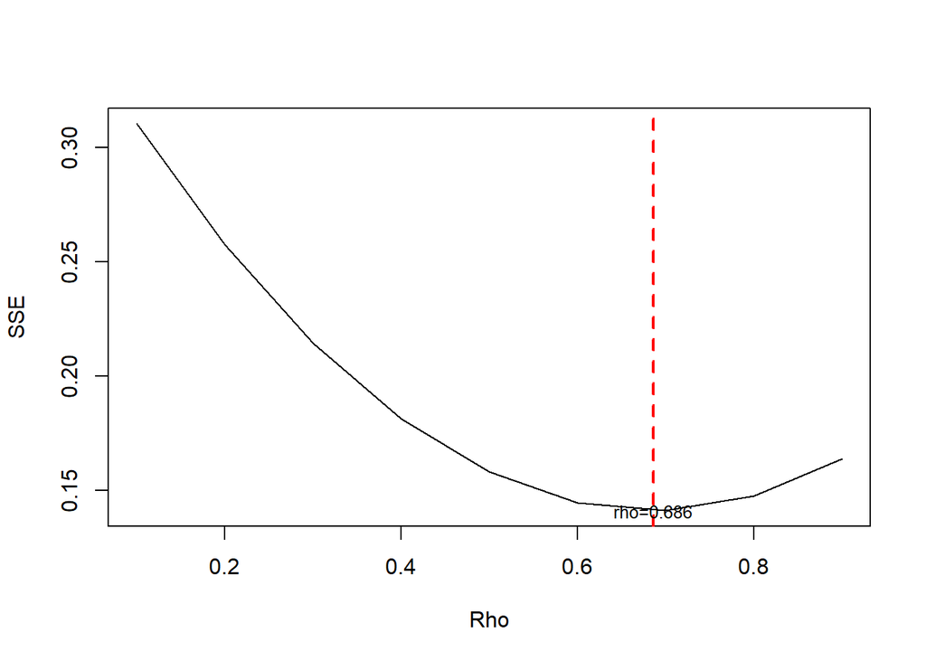

```r
#Grafik SSE optimum
par(mfrow = c(1,1))
plot(tab$SSE ~ tab$rho , type = "l", xlab = "Rho", ylab = "SSE")
abline(v = tabOpt[tabOpt$SSE==min(tabOpt$SSE),"rho"], lty = 2, col="red",lwd=2)
text(x=0.686, y=0.1409665, labels = "rho=0.686", cex = 0.8)
```

Diperoleh grafik konvergen menuju rho 0.686, yang artinya SSE minimum pada nilai rho tersebut.

```r
modelhlni <- hildreth.lu(dt_ipmni$ipmni, dt_ipmni$tahunni, rho = 0.686)
summary(modelhlni)
```

```
##
## Call:
## lm(formula = y ~ x)
##
## Residuals:
##      Min       1Q   Median       3Q      Max
## -0.23553 -0.09561  0.01474  0.03301  0.20925
##
## Coefficients:
##               Estimate Std. Error t value Pr(>|t|)
## (Intercept) -169.95451   37.02880  -4.590  0.00251 **
## x              0.30858    0.05834   5.289  0.00114 **
## ---
## Signif. codes:  0 '***' 0.001 '**' 0.01 '*' 0.05 '.' 0.1 ' ' 1
##
## Residual standard error: 0.1419 on 7 degrees of freedom
## Multiple R-squared:  0.7998, Adjusted R-squared:  0.7713
## F-statistic: 27.97 on 1 and 7 DF,  p-value: 0.001137
```

```r
#Transformasi Balik
cat("y = ", coef(modelhlni)[1]/(1-0.686), "+", coef(modelhlni)[2],"x", sep = "")
```

```
## y = -541.2564+0.3085849x
```

```r
#Deteksi autokorelasi
dwtest(modelhlni)
```

```
##
##  Durbin-Watson test
##
## data:  modelhlni
## DW = 1.9334, p-value = 0.2856
## alternative hypothesis: true autocorrelation is greater than 0
```

Setelah dilakukan penanganan menggunakan metode Hidreth-LU diperoleh nilai dw menedekati 2 yang artinya masalah autokorelasi sudah tertangani.

```r
sse_awal <- sum(residuals(model_awal1)^2)
sse_co <- sum(residuals(model_coni)^2)
sse_hl <- sum(residuals(modelhlni)^2)

data.frame(
  Metode = c("Model Awal (Sakit)", "Cochrane-Orcutt (Sehat)", "Hildreth-Lu (Sehat)"),
  SSE = c(sse_awal, sse_co, sse_hl),
  DW_Statistic = c(dwtest(model_awal1)$statistic, model_coni$DW[3], dwtest(modelhlni)$statistic)
)
```

```
##                    Metode       SSE DW_Statistic
## 1      Model Awal (Sakit) 0.5738473     0.587081
## 2 Cochrane-Orcutt (Sehat) 4.0776458     1.932898
## 3     Hildreth-Lu (Sehat) 0.1409665     1.933428
```

Model awal memiliki autokorelasi dengannilai Durbin–Watson 0,587 yang menandakan autokorelasi positif yang kuat. Setelah dikoreksi dengan Cochrane–Orcutt maupun Hildreth–Lu memberi DW ≈ 1,93 (mendekati 2), yang artinya autokorelasi sudah teratasi, serta di antara keduanya, Hildreth–Lu menghasilkan hasil yang lebih baik karena SSE-nya paling kecil sebesar 0.1409665, sedangkan SSE CO lebih besar.